# 第5回 正則化による多重共線性の問題への対処

列を増やしても、説明できる係数を保つ

# 導入

## 場面：前回と同じ査定担当者

① 場面●○○

- あなたは、前回と同じ、エイムズ市の住宅の査定担当者
- 値段を見積もり、その理由を条件ごとにお客さんに説明する

## 前回の答え

① 場面●●○

- 似た2列のうち、車庫の台数を外した10本の式で査定した
- 交差検証のMAEは19,297ドル。係数は揺れずに読めた

## 列は80本ある

① 場面●●●

- データには80本の列がある。列を増やせば、もっと当たるかもしれない
- そのかわり、似た列も増える。1本ずつ手で外すのは、もう無理

## 手元のデータ

② 手元のデータ●○

- 前回と同じ、エイムズ市の住宅の売買。2,412軒を使う
- 今日は、手がかりの数の列を30本に増やす

## 10本から30本へ

② 手元のデータ●●

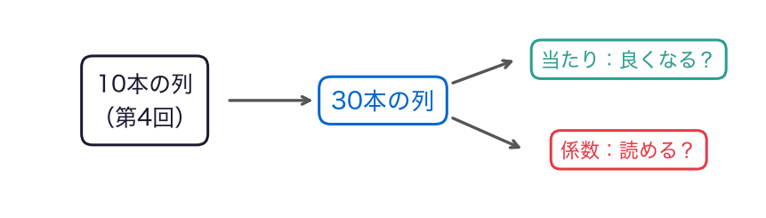

- 当たりは良くなるのか。係数は読めるのか

## 最後に出す答え

③ 今日の問い●○

- 30本の列で当たりを良くした、査定に使う式
- その式の係数で言える説明と、1軒の家の査定額

## 今日の問い

③ 今日の問い●●

列を増やして当たりを良くしながら、お客さんに説明できる係数を保てるか？

## もう1つのねらい：ドキュメント

④ もう1つのねらい●○

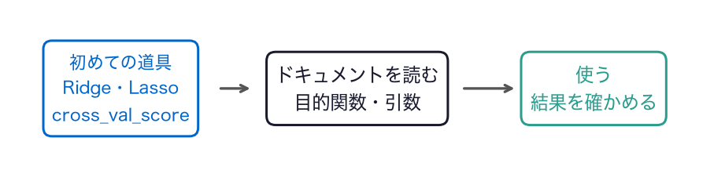

- 初めての道具でも、ドキュメントで引数を読んでから使えるようになる

## ドキュメントで何を読むか

④ もう1つのねらい●●

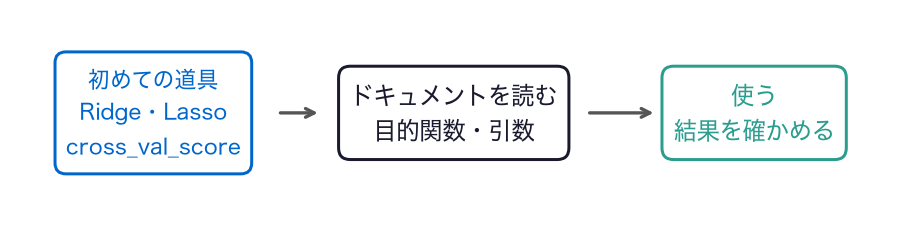

- 道具が最小にする式（目的関数）と、引数の意味と既定値
- モデルを関数の引数にして、交差検証の部品を差し替える

## この問いにどう近づくか

⑤ 今日の問い●○

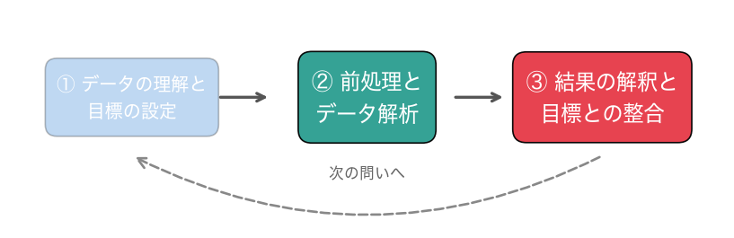

今日は、②の解析（正則化）と、③の解釈が中心です。

## 今日の道筋

⑤ 今日の問い●●

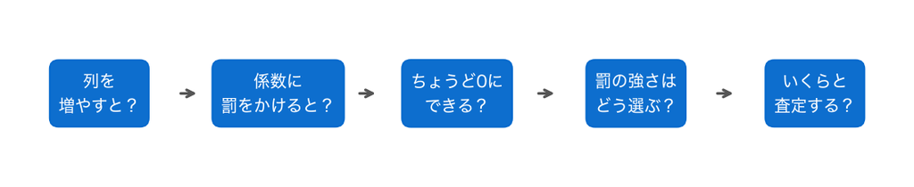

- 5つの小さな問いに答えていく

# 0. 準備

## まずは道具とデータ

- 第5回のノートを開き、上から順にセルを実行する
- 道具を呼び出し、30本の列を用意する

## お手本：道具を呼び出す

0節 ① 道具とデータ●○○○

```python
import numpy as np
import pandas as pd
import matplotlib.pyplot as plt
from sklearn.linear_model import LinearRegression, Ridge, Lasso
from sklearn.model_selection import KFold, cross_val_score
```

- 今日は`Ridge`・`Lasso`・`cross_val_score`が加わる

## お手本：表を読み込む

0節 ① 道具とデータ●●○○

- 第4回と同じ`rename`で、33本の列名を日本語にする
- 中身はノートの表で確かめる。読み込んだのは2,930件

## 使わない数の列

0節 ① 道具とデータ●●●○

- 区分を番号で表した列（番号の大小に意味がない）
- 売れた月と年、その他の設備の金額
- 欠測の理由が分からない間口の長さ、車庫の無い家で空欄の「車庫を建てた年」

## 変えてみる：絞って㎡に直す

0節 ① 道具とデータ●●●●

```python
normal = raw['売買の条件'] == 'Normal'     # ふつうの売買
small = raw['居住面積'] <= 4000            # 広すぎない家
df = raw[normal & small].reset_index(drop=True)
area = ['敷地面積', '石張りの面積', '地下の仕上げ1', '地下の仕上げ2',
        '地下の未仕上げ', '地下の面積', '1階の面積', '2階の面積',
        '低品質の面積', '居住面積', '車庫の面積', 'ウッドデッキ',
        '開放ポーチ', '囲いポーチ', '三季ポーチ', '網戸ポーチ',
        'プールの面積']
for c in area:
    df[c] = df[c] * 0.0929                 # 平方フィート → ㎡
print(len(df), '軒')
```

[output not shown]

- 第4回と同じ2,412軒。面積の17本を㎡に直す

## 欠測は、まず理由を確かめる

0節 ② 欠測の理由●○○○○

- 第3回で学んだとおり、すぐに1つの値で補完しない
- 30本の列の欠測を数え、欠測した家の様子を見る

## 3つの列が欠測

0節 ② 欠測の理由●●○○○

```
石張りの面積      11
地下のバスルーム     1
地下の洗面所       1
```

- 石張りの面積が11件、地下のバスルームと地下の洗面所が1件ずつ

## 種類も空欄なら、石張りは無い

0節 ② 欠測の理由●●●○○

```
1474 1481
```

- 種類が空欄で面積の分かる家1,481軒のうち、1,474軒は面積0
- 欠測した11件も種類が空欄。石張りの無い家として0に戻す

## 地下室が無ければ0

0節 ② 欠測の理由●●●●○

```
      地下の面積
1301    0.0
```

- 地下のバスルームが欠測した家は、地下の面積が0
- 地下室が無いので、地下のバスルームも洗面所も0

## お手本：0に戻す

0節 ② 欠測の理由●●●●●

```python
fill0 = ['石張りの面積', '地下のバスルーム', '地下の洗面所']
df[fill0] = df[fill0].fillna(0)
print(df[cols].isna().sum().sum(), '件')
```

[output not shown]

- ほかの列から真の値（0）が分かる欠測。平均で埋めず、0に戻す
- 30本の列の欠測は0件になった

## 欠測を残すと式は作れない

0節 ③ 補完か使わないか●○○○○○○○

- 線形回帰もリッジもラッソも、`NaN`が1つでもあると止まる
- 第3回で見た`ValueError: Input X contains NaN.`
- 使う列の欠測は、式を作る前に必ずなくす

## 欠測をなくす3つの方法

0節 ③ 補完か使わないか●●○○○○○○

1. 真の値がほかの列から分かるなら、戻す（今日の石張り・地下のバスルーム）
2. ほかの列から予測して補完する（第3回の回帰補完）
3. その列や行を、使わない

## 補完は、どこまでも推測

0節 ③ 補完か使わないか●●●○○○○○

- 第3回は、2の補完を中心に学んだ
- でも、補完した値は推測。使わないほうがよい場合もある

## 使わないほうがよい場合

0節 ③ 補完か使わないか●●●●○○○○

- 値がそもそも存在しない（車庫の無い家の、車庫を建てた年）
- 欠けた理由が分からず、欠けが多い
- 測った値そのものが信頼できない

## 遺伝子データの低発現遺伝子

0節 ③ 補完か使わないか●●●●●○○○

- 発現量が測定の下限に近い遺伝子は、値が欠けたり雑音ばかりだったりする
- 補完せず、解析の前に外すのがふつう
- 発展のラットの目のデータも、元の論文は発現している遺伝子だけを解析

## お手本：間口の長さを見る

0節 ③ 補完か使わないか●●●●●●○○

```python
frontage = raw.loc[normal & small, 'Lot Frontage']
frontage = frontage.reset_index(drop=True)   # df と行番号をそろえる
print(frontage.isna().sum(), round(frontage.isna().mean() * 100, 1))
print(df.groupby(frontage.isna())[['敷地面積', '価格']].median())
```

```
451 18.7
                  敷地面積        価格
Lot Frontage
False         849.4776  155000.0
True          960.3073  173000.0
```

## 欠けた家は高め

0節 ③ 補完か使わないか●●●●●●●○

- 451件（18.7%）が欠ける。欠けた家（True）は敷地が広く、価格も高め
- でたらめな欠け方ではない。どんな理由で欠けたかは、データから分からない

## 使わないと決め、書き残す

0節 ③ 補完か使わないか●●●●●●●●

- 補完の良し悪しを確かめるには、答えの分かる欠測を作って評価する（第3回）
- 今日はその手間をかけず、間口の長さは使わない
- 使わないと決めたことと理由を書き残すのも、前処理の仕事

## やってみよう：0節

0節 ④ 確かめる●

- 0節のセルを上から実行し、2,412軒・30本・欠測0件を確かめる

動画の人は、ここで一時停止。

# 1. 列を増やすと？

## まず当たりを測る

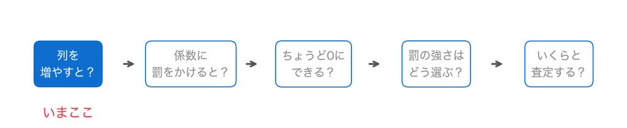

- 30本の列がそろった
- 第4回と同じ交差検証で、列を増やした式の当たりを測る

## おさらい：第4回の関数

1節 ① 10本と30本●○○○○

```python
def mae(y, pred):          # MAE
    return round(np.abs(y - pred).mean())

kf = KFold(n_splits=5, shuffle=True, random_state=0)

def cv_score(cols, watch):
    rows = []
    for tr_i, te_i in kf.split(df):
        tr_s, te_s = df.iloc[tr_i], df.iloc[te_i]
        m_s = LinearRegression().fit(tr_s[cols], tr_s['価格'])
        coef_s = pd.Series(m_s.coef_, index=cols)
        pred_s = m_s.predict(te_s[cols])
        rows.append({'MAE': mae(te_s['価格'], pred_s),
                     '係数': round(coef_s[watch])})
    return pd.DataFrame(rows)
```

## 第4回からの変更

1節 ① 10本と30本●●○○○

- 係数を見る列`watch`は、毎回指定するので既定値を外した
- RMSEは省いた。5回分のMAEと係数の表を返す

## お手本：10本と30本

1節 ① 10本と30本●●●○○

```python
feat10 = ['品質', '居住面積', '地下の面積', '車庫の面積',
          '建てた年', '改装した年', 'バスルーム数', '部屋数',
          '暖炉の数', '敷地面積']
cv10 = cv_score(feat10, '居住面積')
cv30 = cv_score(cols, '居住面積')
print(pd.DataFrame({'10本のMAE': cv10['MAE'],
                    '30本のMAE': cv30['MAE'],
                    '10本の係数': cv10['係数'],
                    '30本の係数': cv30['係数']}))
print(round(cv10['MAE'].mean()), round(cv30['MAE'].mean()))
```

## 当たりは2千ドル良くなる

1節 ① 10本と30本●●●●○

```
   10本のMAE  30本のMAE  10本の係数  30本の係数
0    19386    17932     675     431
1    19458    17140     681     462
2    19408    16791     682     396
3    18862    17082     705     437
4    19369    16996     686     358
19297 17188
```

- 10本は19,297ドル（第4回と同じ）、30本は17,188ドル

## でも居住面積の係数は？

1節 ① 10本と30本●●●●●

```
   10本のMAE  30本のMAE  10本の係数  30本の係数
0    19386    17932     675     431
1    19458    17140     681     462
2    19408    16791     682     396
3    18862    17082     705     437
4    19369    16996     686     358
```

- 10本では1㎡あたり675〜705ドル、30本では358〜462ドル
- 小さくなったうえに、回ごとの揺れも大きい

## 新しく加わった列に

1節 ② 居住面積は何の和●○○○○

- `1階の面積`・`2階の面積`・`低品質の面積`が加わった
- 居住面積は、この3つの和と同じではないか

## TODO①：居住面積は何の和？

1節 ② 居住面積は何の和●●○○○

```python
# TODO: 居住面積から3つの列の和を引いた差の、大きさの最大値を表示する
# ヒント: diff = df['居住面積'] - (df['1階の面積'] + … ) のあと、
#         np.abs(diff).max()
...
```

- 2,412軒それぞれで差を計算し、その大きさの最大値を出す

## やってみよう：1節とTODO①

1節 ② 居住面積は何の和●●●○○

- 1節のお手本を実行し、10本と30本のMAEと係数を比べる
- TODO①で、居住面積と3つの列の和の差を確かめる

動画の人は、ここで一時停止。

## 答え合わせ：TODO①

1節 ② 居住面積は何の和●●●●○

```python
diff = df['居住面積'] - (df['1階の面積'] + df['2階の面積']
                       + df['低品質の面積'])
print(np.abs(diff).max())
```

```
5.684341886080802e-14
```

- `5.68e-14`は0.0000000000000568。小数の計算の丸めで、0と見なせる

## 居住面積は3つの和

1節 ② 居住面積は何の和●●●●●

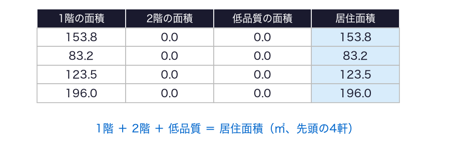

- 2,412軒すべてで、居住面積は1階・2階・低品質の面積の和

## 居住面積だけを1増やせるか？

1節 ③ 完全な多重共線性●○○○○

- 係数は「ほかの列を同じにしたまま、その列を1増やすと」の値
- 1階・2階・低品質を同じにしたまま、居住面積だけを1㎡増やせるか

## やってみよう：問いを書く

1節 ③ 完全な多重共線性●●○○○

- ノートの「問い」の欄に、考えを書く

動画の人は、ここで一時停止。

## そんな家はあり得ない

1節 ③ 完全な多重共線性●●●○○

- 居住面積は3つの和。3つを同じにしたまま増やせない
- 「ほかを同じにしたら」という読み方が、成り立たない

## 和は決まり、内訳は決まらない

1節 ③ 完全な多重共線性●●●●○

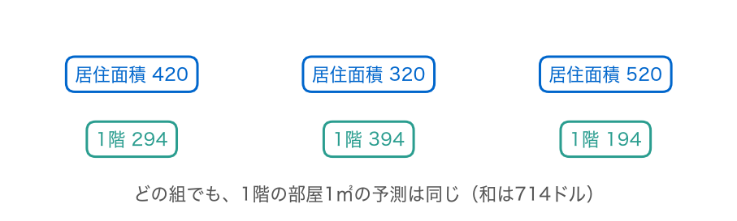

- 居住面積の係数から100引き、1階に100足しても、予測は同じ

## 名前：完全な多重共線性

1節 ③ 完全な多重共線性●●●●●

- 足すとほかの列にぴったり一致する列がある
- 係数の内訳がまったく決まらない。これを完全な多重共線性と呼ぶ
- 地下の面積も、仕上げ1・仕上げ2・未仕上げの和

## お手本：30本の係数を見る

1節 ④ 読みにくい係数●○○○

```python
m30 = LinearRegression().fit(df[cols], df['価格'])
print(pd.Series(m30.coef_, index=cols).round(0))
```

- 2,412軒すべてで、30本の列の式を作り、係数を並べる

## 読みにくい係数が並ぶ

1節 ④ 読みにくい係数●●○○

```
              列  係数          列   係数
        敷地面積     7 地下の洗面所  -3838
            品質 13601 バスルーム数  -2475
            状態  4612   洗面所の数  -1664
        建てた年   340       寝室数  -9025
      改装した年   196   キッチン数 -18377
    石張りの面積   309       部屋数   2282
   地下の仕上げ1   192     暖炉の数   2496
   地下の仕上げ2    62   車庫の台数   1099
  地下の未仕上げ   -22   車庫の面積    252
      地下の面積   232 ウッドデッキ    142
       1階の面積   294   開放ポーチ    135
       2階の面積   231   囲いポーチ    200
    低品質の面積  -105   三季ポーチ   -237
        居住面積   420   網戸ポーチ    405
地下のバスルーム  2195 プールの面積   -221
```

## キッチンが多いと安い？

1節 ④ 読みにくい係数●●●○

- キッチン数は−18,377ドル、寝室数は−9,025ドル
- 係数の多くは、似た列と内訳を分け合っている

## 当たりと説明の板ばさみ

1節 ④ 読みにくい係数●●●●

- 列を増やすと、当たりは良くなった
- でも、お客さんに説明できる係数は、遠のいた

# 2. 係数に罰をかけると？

## 内訳を1つに決めたい

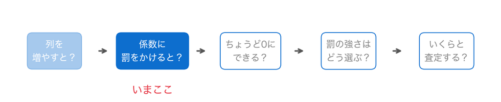

- 内訳が決まらないなら、候補の中から1つを選ぶ決まりを足せないか

## 誤差の二乗和だけでは

2節 ① 罰を足す●○○

- 普通の線形回帰は、誤差の二乗和が最も小さい係数を選ぶ
- 内訳が決まらないときは、同じ最小値になる係数がいくつもある

## 係数の大きさに罰を足す

2節 ① 罰を足す●●○

$$\sum_{i=1}^{n} (y_i - \hat{y}_i)^2 + \alpha \sum_{j=1}^{p} b_j^2$$

- $b_j$は係数、$p$は列の数（30）、$\alpha$は罰の強さ
- 誤差がほとんど同じなら、係数が小さいほうが選ばれる

## 名前：正則化とリッジ回帰

2節 ① 罰を足す●●●

- 係数の大きさに罰をかけて係数を選ぶことを、正則化と呼ぶ
- 係数の二乗の和に罰をかける方法を、リッジ回帰と呼ぶ
- $\alpha = 0$なら罰が無く、普通の線形回帰と同じ

## 罰はどの係数にも同じ強さ

2節 ② 標準化●○

- 係数の大きさは、列の目盛りで変わる
- 平方フィートで測れば1単位が小さく、係数も小さくなる
- 目盛りしだいで、罰の効き方が変わってしまう

## 罰の前に、目盛りをそろえる

2節 ② 標準化●●

$$z_{ij} = \frac{x_{ij} - \bar{x}_j}{s_j}$$

- 第3回の標準化。どの列も平均0・標準偏差1にそろえる
- $\bar{x}_j$と$s_j$は、訓練の家だけで決める

## 初めての道具はドキュメントから

2節 ③ ドキュメント●○○○

- `Ridge`は初めて使う道具
- 使う前に、ドキュメント（説明書き）を読む

## お手本：ドキュメントを表示

2節 ③ ドキュメント●●○○

```python
help(Ridge)
```

- `help(道具の名前)`で、その道具のドキュメントが表示される
- 長いので、最初の部分と、Parametersの`alpha`の項だけ読む

## 最初の数行：目的関数

2節 ③ ドキュメント●●●○

```
Minimizes the objective function::

||y - Xw||^2_2 + alpha * ||w||^2_2
```

- `||y - Xw||^2_2`が誤差の二乗和、`||w||^2_2`が係数の二乗の和
- `w`が係数。さっき書いた式と同じ

## Parameters：alpha

2節 ③ ドキュメント●●●●

```
alpha : float or array-like of shape (n_targets,), default=1.0
    Constant that multiplies the L2 term, controlling regularization
    strength. `alpha` must be a non-negative float i.e. in `[0, inf)`.
```

- 「L2の項（二乗の和）に掛ける定数で、正則化の強さを決める。0以上」
- 1行目は「名前 : 型, 既定値」。既定値は1.0

## おさらい：標準化の関数

2節 ④ cv_model●○○○○○○

```python
def standardize(X, mean, std):
    return (X - mean) / std
```

- 第3回で書いた関数。訓練で決めた平均と標準偏差を引数で受け取る

## 標準化は各回の中で

2節 ④ cv_model●●○○○○○

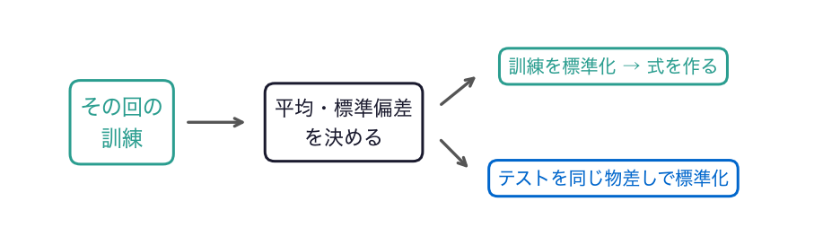

- 交差検証の各回で、その回の訓練の物差しを決める

## cv_scoreからの変更は2つ

2節 ④ cv_model●●●○○○○

- 「式を作る」部品を、引数`model`で受け取る
- 毎回、訓練の物差しで訓練とテストを標準化してから式を作る

## お手本：モデルを引数に

2節 ④ cv_model●●●●○○○

```python
def cv_model(cols, model, watch):
    rows = []
    for tr_i, te_i in kf.split(df):
        tr_s, te_s = df.iloc[tr_i], df.iloc[te_i]
        mean, std = tr_s[cols].mean(), tr_s[cols].std()  # 訓練で
        Z_tr = standardize(tr_s[cols], mean, std)
        Z_te = standardize(te_s[cols], mean, std)
        m_s = model.fit(Z_tr, tr_s['価格'])
        coef_s = pd.Series(m_s.coef_, index=cols) / std  # 1単位に
        rows.append({'MAE': mae(te_s['価格'], m_s.predict(Z_te)),
                     '係数': round(coef_s[watch]),
                     '0の数': (m_s.coef_ == 0).sum()})
    return pd.DataFrame(rows)

print(cv_model(cols, LinearRegression(), '居住面積'))
```

## 1行ずつ読む

2節 ④ cv_model●●●●●○○

- `model.fit`：渡されたモデルで式を作る。`LinearRegression()`も`Ridge(alpha=100)`も渡せる
- `/ std`：標準化した目盛りの係数を、元の1単位あたりのドルに戻す
- `0の数`：係数がちょうど0の列の数。3節で使う

## 普通の式なら1節と同じ当たり

2節 ④ cv_model●●●●●●○

```
     MAE   係数  0の数
0  17932  385    0
1  17140  398    0
2  16791  383    0
3  17082  389    0
4  16996  391    0
```

- MAEは1節と同じ5つの数。標準化しても予測は変わらない

## 係数だけが変わった

2節 ④ cv_model●●●●●●●

```
     MAE   係数  0の数
0  17932  385    0
1  17140  398    0
2  16791  383    0
3  17082  389    0
4  16996  391    0
```

## 変えてみる：リッジを渡す

2節 ⑤ リッジ●○○○○○○

```python
ridge = cv_model(cols, Ridge(alpha=100), '居住面積')
print(ridge)
print(ridge['MAE'].mean())
```

- 渡すモデルを`Ridge(alpha=100)`に変えるだけ

## 揺れが小さくなった

2節 ⑤ リッジ●●○○○○○

```
     MAE   係数  0の数
0  17880  340    0
1  16997  350    0
2  16809  338    0
3  16926  343    0
4  16917  343    0
17105.8
```

- MAEは17,106ドル。居住面積の係数は338〜350ドルで、揺れが小さい

## 内訳が1つに決まった

2節 ⑤ リッジ●●●○○○○

- 罰をかけたので、内訳が1つに決まった
- 当たりは、普通の線形回帰（17,188ドル）とほとんど同じ

## 変えてみる：1階と2階も

2節 ⑤ リッジ●●●●○○○

```python
print(cv_model(cols, Ridge(alpha=100), '1階の面積')['係数'].values)
print(cv_model(cols, Ridge(alpha=100), '2階の面積')['係数'].values)
```

```
[308 304 288 295 302]
[205 228 223 216 224]
```

## 3つの列で分け合う

2節 ⑤ リッジ●●●●●○○

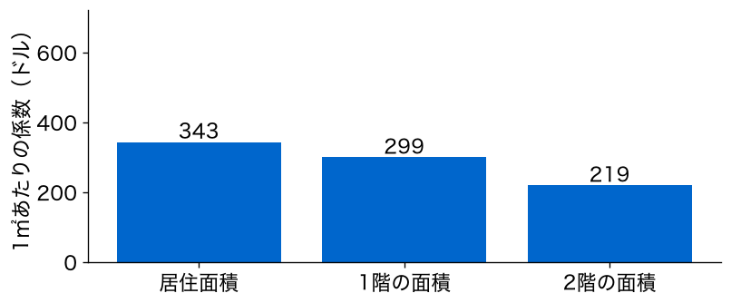

- 1階の面積は288〜308ドル、2階の面積は205〜228ドル

## なぜ分け合うのか

2節 ⑤ リッジ●●●●●●○

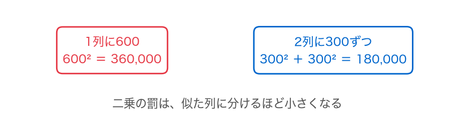

- 二乗の罰は、1列に集めるより、似た列に分けたほうが小さい

## 説明にはまだ使いにくい

2節 ⑤ リッジ●●●●●●●

- 「居住面積1㎡あたり約340ドル」と言うと、1階や2階の分を見落とす
- 揺れは小さくなったが、似た列に分かれたまま

## やってみよう：2節

2節 ⑥ 確かめる●

- 2節のお手本と「変えてみる」のセルを実行する
- リッジで、居住面積・1階・2階の係数を確かめる

動画の人は、ここで一時停止。

# 3. 係数をちょうど0にできる？

## 1本に集めたい

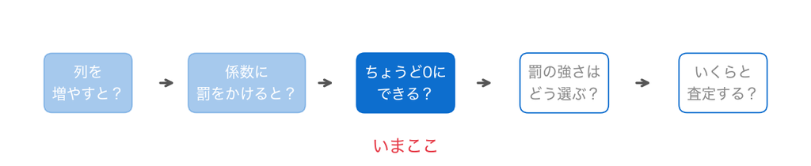

- 説明しやすいのは、似た列の1本に係数を集め、残りを0にした式
- 外す列を、式に選ばせられないか

## 絶対値の罰：ラッソ

3節 ① ラッソ●○○

$$\frac{1}{2n}\sum_{i=1}^{n} (y_i - \hat{y}_i)^2 + \alpha \sum_{j=1}^{p} \lvert b_j \rvert$$

- 罰を、係数の二乗の和から、絶対値の和に変える
- この方法を、ラッソ（Lasso）と呼ぶ

## 0まで同じ強さで引っぱる

3節 ① ラッソ●●○

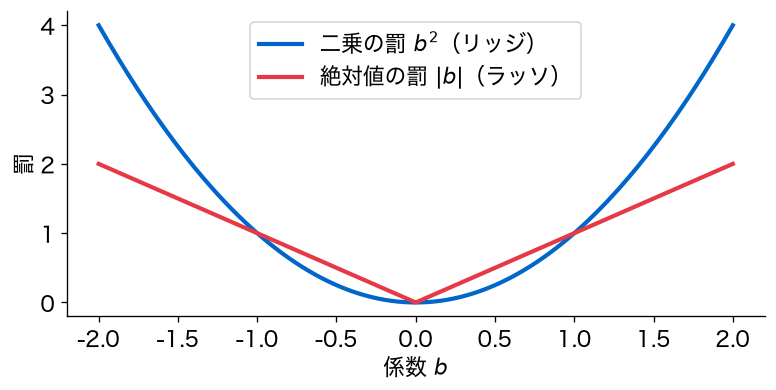

- 二乗の罰は0の近くで弱まる。絶対値の罰は0まで同じ強さ

## ちょうど0になる

3節 ① ラッソ●●●

- 効きの弱い列の係数は、ちょうど0になる
- 0になった列は、式から外れたのと同じ

## お手本：Lassoのドキュメント

3節 ② ドキュメント●○○

```python
help(Lasso)
```

- 最初の部分の目的関数を、リッジと比べて読む

## 目的関数をリッジと比べる

3節 ② ドキュメント●●○

```
The optimization objective for Lasso is::

    (1 / (2 * n_samples)) * ||y - Xw||^2_2 + alpha * ||w||_1
```

- `||w||_1`が係数の絶対値の和
- 誤差の二乗和の前に`(1 / (2 * n_samples))`が付いている

## alphaの物差しが違う

3節 ② ドキュメント●●●

- 誤差の二乗和を$2n$（約3,900）で割ってから、罰と比べる
- 同じ`alpha`の数でも、リッジとはまったく違う強さになる
- 名前から想像せず、ドキュメントの式で確かめる

## お手本：ラッソを渡す

3節 ③ 0になる列●○○○○○○○○

```python
lasso = cv_model(cols, Lasso(alpha=300), '居住面積')
print(lasso)
print(lasso['MAE'].mean())
```

- `cv_model`に渡すモデルを`Lasso(alpha=300)`に変える

## 3〜5本がちょうど0

3節 ③ 0になる列●●○○○○○○○

```
     MAE   係数  0の数
0  17890  609    5
1  17155  629    4
2  16766  624    3
3  17044  622    5
4  16885  628    3
17148.0
```

- MAEは17,148ドル。毎回3〜5本の係数がちょうど0になった

## 居住面積が戻ってきた

3節 ③ 0になる列●●●○○○○○○

```
     MAE   係数  0の数
0  17890  609    5
1  17155  629    4
2  16766  624    3
3  17044  622    5
4  16885  628    3
```

- 居住面積の係数は609〜629ドル。第4回の10本の式（675〜705ドル）に近い

## どの列が0になった？

3節 ③ 0になる列●●●●○○○○○

- 2,412軒すべてで、標準化してラッソの式を作る
- 物差しは、全部の家の平均と標準偏差

## お手本：0の列を表示

3節 ③ 0になる列●●●●●○○○○

```python
mean_all, std_all = df[cols].mean(), df[cols].std()
Z_all = standardize(df[cols], mean_all, std_all)
lasso_all = Lasso(alpha=300).fit(Z_all, df['価格'])
coef = pd.Series(lasso_all.coef_, index=cols)
print(list(coef[coef == 0].index))
```

- `coef[coef == 0]`は、係数が0の列だけを取り出す（条件で絞る）

## 4本が0になった

3節 ③ 0になる列●●●●●●○○○

```
['地下の未仕上げ', '2階の面積', 'バスルーム数', '洗面所の数']
```

- 地下の未仕上げ・2階の面積・バスルーム数・洗面所の数

## 和でつながった組から1本

3節 ③ 0になる列●●●●●●●○○

- 2階の面積は、居住面積から1階を引けばほぼ分かる
- 地下の未仕上げも、地下の面積と2つの仕上げから分かる
- 和でつながった組の中から、ラッソは1本を外した

## バスルームは関係ない？

3節 ③ 0になる列●●●●●●●●○

- バスルーム数と洗面所の数も0になった
- 第4回で「居住面積・部屋数と合わせて読む」とした列

## 重なる列を外しただけ

3節 ③ 0になる列●●●●●●●●●

- ほかの列が持っている情報と重なる列を外した
- バスルームが価格に関係ない、という意味ではない

## やってみよう：3節

3節 ④ 確かめる●

- 3節のお手本を実行し、0になった列を確かめる
- 居住面積の係数を、リッジのときと比べる

動画の人は、ここで一時停止。

# 4. 罰の強さは、どう選ぶ？

## alphaはどう決める？

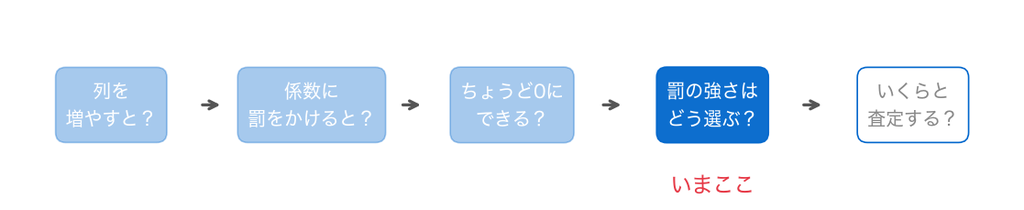

- ここまで、リッジに100、ラッソに300を使った
- この値は、どう決めればよいのか

## 交差検証で選ぶ

4節 ① リッジのalpha●○○○○

- `alpha`を変えると当たりが変わる
- 式を比べる標準の物差しは、交差検証だった（第4回）
- `alpha`ごとに交差検証のMAEを測り、いちばん小さい値を選ぶ

## テストで選ばない

4節 ① リッジのalpha●●○○○

- テストの家で`alpha`を選ぶと、テストに合わせたことになる
- まだ見ていない家での当たりを、甘く見積もってしまう

## お手本：リッジのalpha

4節 ① リッジのalpha●●●○○

```python
rows = []
for a in [1, 10, 30, 100, 300, 1000]:
    res = cv_model(cols, Ridge(alpha=a), '居住面積')
    rows.append({'alpha': a, 'MAE': res['MAE'].mean(),
                 '居住面積の係数': res['係数'].mean()})
print(pd.DataFrame(rows))
```

- `for`文で`alpha`を変え、`cv_model`を部品として呼ぶ

## alpha=100で最小

4節 ① リッジのalpha●●●●○

```
   alpha      MAE  居住面積の係数
0      1  17187.0    388.6
1     10  17174.2    383.2
2     30  17152.4    372.6
3    100  17105.8    342.8
4    300  17123.4    292.0
5   1000  17546.6    223.4
```

- MAEは`alpha`が100のとき17,106ドルでいちばん小さい
- `alpha`が大きいほど、居住面積の係数は縮む

## 罰は弱すぎても強すぎても

4節 ① リッジのalpha●●●●●

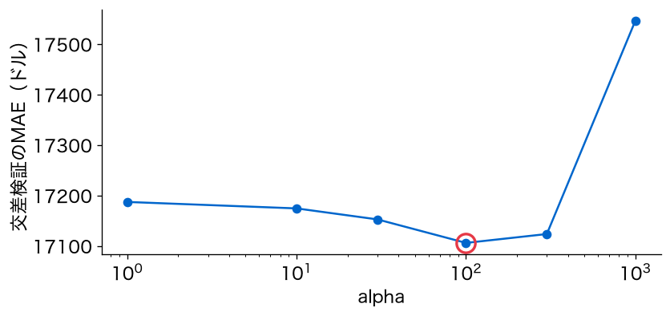

- 横軸は対数の目盛り（`plt.xscale('log')`）。100のところで谷になる

## TODO②：ラッソのalpha

4節 ② ラッソのalpha●○○○○

```python
# TODO: alpha を 10〜3000 に変えてラッソを評価し、表にする
# ヒント: リッジのセルを写し、Ridge を Lasso に変える。
#         rows.append の辞書に '0の数': res['0の数'].mean() を足す
...
```

- `alpha`は10・30・100・300・1000・3000

## やってみよう：4節とTODO②

4節 ② ラッソのalpha●●○○○

- 4節のお手本を実行し、リッジの`alpha`の表と図を確かめる
- TODO②で、ラッソの`alpha`の表を作る

動画の人は、ここで一時停止。

## 答え合わせ：TODO②

4節 ② ラッソのalpha●●●○○

```python
rows = []
for a in [10, 30, 100, 300, 1000, 3000]:
    res = cv_model(cols, Lasso(alpha=a), '居住面積')
    rows.append({'alpha': a, 'MAE': res['MAE'].mean(),
                 '居住面積の係数': res['係数'].mean(),
                 '0の数': res['0の数'].mean()})
print(pd.DataFrame(rows))
```

## alpha=300で最小

4節 ② ラッソのalpha●●●●○

```
   alpha      MAE  居住面積の係数   0の数
0     10  17186.4    232.6   1.0
1     30  17182.2    467.0   1.0
2    100  17172.0    635.8   2.2
3    300  17148.0    622.4   4.0
4   1000  17193.0    609.6   9.8
5   3000  17717.2    503.8  15.6
```

- MAEは`alpha`が300のとき17,148ドルでいちばん小さい

## 強めるほど0が増える

4節 ② ラッソのalpha●●●●●

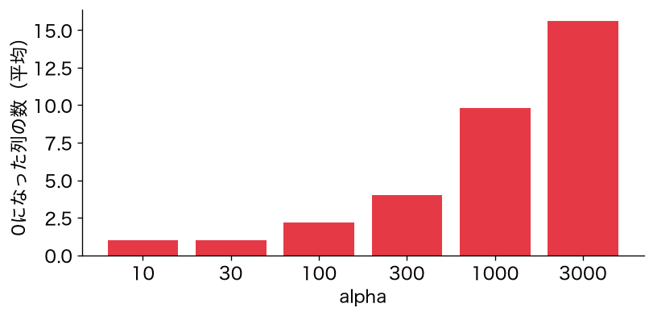

- 0の列は、10や30で1本、300で4本、1000で9.8本、3000で15.6本

## 赤い警告が出た

4節 ③ 警告とmax_iter●○○○○

- セルの出力に`ConvergenceWarning`という警告が出た
- `alpha`が10や30の居住面積の係数（233ドル、467ドル）も不自然

## 警告を読む

4節 ③ 警告とmax_iter●●○○○

```
ConvergenceWarning: Objective did not converge. You might want to
increase the number of iterations, ...
```

- 目的関数の最小値にたどり着かなかった（収束しなかった）
- くり返しの回数を増やすとよいかもしれない

## ドキュメントでmax_iterを読む

4節 ③ 警告とmax_iter●●●○○

```
max_iter : int, default=1000
    The maximum number of iterations.
```

- ラッソは計算をくり返して最小値を探す。罰が弱いと回数が要る
- くり返しの上限は`max_iter`。既定値は1000回

## お手本：max_iterを大きく

4節 ③ 警告とmax_iter●●●●○

```python
print(cv_model(cols, Lasso(alpha=10, max_iter=100000), '居住面積'))
```

```
     MAE   係数  0の数
0  17931  627    2
1  17139  669    2
2  16789  645    2
3  17080  643    2
4  16991  656    2
```

- 警告は消え、居住面積の係数は627〜669ドルになった

## 警告は読み飛ばさない

4節 ③ 警告とmax_iter●●●●●

- 収束していない式の係数は、途中の値で、信じられない
- 警告は、ドキュメントで対処を確かめる

## ライブラリにも交差検証がある

4節 ④ cross_val_score●○○○○○○

- scikit-learnにも、交差検証の道具`cross_val_score`がある
- 自分の関数と同じ数が出るか、確かめる

## お手本：ドキュメントを表示

4節 ④ cross_val_score●●○○○○○

```python
help(cross_val_score)
```

- Parametersの`scoring`（何で評価するか）を読む

## scoringの名前

4節 ④ cross_val_score●●●○○○○

```
scoring : str or callable, default=None
    Strategy to evaluate the performance of the `estimator`
    across cross-validation splits.
```

- 物差しの名前を文字で渡す。名前の一覧はウェブのUser Guideにある
- MAEの名前は`'neg_mean_absolute_error'`

## negはマイナス

4節 ④ cross_val_score●●●●○○○

- scikit-learnの物差しは「値が大きいほど良い」にそろえてある
- MAEのように小さいほど良い物差しは、マイナスを付けて返す（User Guide）

## 変えてみる：自分の関数と比べる

4節 ④ cross_val_score●●●●●○○

```python
scores = cross_val_score(LinearRegression(), df[cols], df['価格'],
                         cv=kf, scoring='neg_mean_absolute_error')
print(scores)
print(-scores.mean())
```

- 普通の線形回帰を、1節と同じ5つの組で評価する

## マイナスを付け直すと同じ

4節 ④ cross_val_score●●●●●●○

```
[-17932.29658206 -17140.36655375 -16791.25912733 -17082.27081046
 -16996.14427474]
17188.46746966715
```

- マイナスを付け直した平均は17,188ドル。1節の`cv_score`と同じ

## リッジを渡すときは注意

4節 ④ cross_val_score●●●●●●●

- `cross_val_score`に`Ridge`をそのまま渡すと、標準化をしない
- 標準化を交差検証の中に入れるには、自分の`cv_model`のように書く

# 5. 説明できる係数で査定する

## ラッソを使う

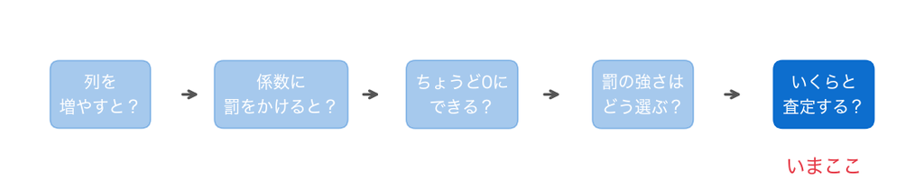

- リッジ（`alpha`=100）は17,106ドル、ラッソ（`alpha`=300）は17,148ドル
- 当たりは同じくらい。係数を1本に集めるラッソのほうが説明しやすい

## お手本：係数をドルで読む

5節 ① 係数を読む●○○○

```python
coef_dollar = pd.Series(lasso_all.coef_, index=cols) / std_all
print(coef_dollar.round(0))
```

- 標準化した目盛りの係数を、標準偏差で割って1単位あたりに戻す

## 査定に使う係数

5節 ① 係数を読む●●○○

```
              列  係数          列   係数
        敷地面積     7 地下の洗面所  -2285
            品質 13953 バスルーム数      0
            状態  4082   洗面所の数      0
        建てた年   292       寝室数  -7829
      改装した年   199   キッチン数 -17708
    石張りの面積   303       部屋数   1513
   地下の仕上げ1   211     暖炉の数   2583
   地下の仕上げ2    66   車庫の台数    730
  地下の未仕上げ     0   車庫の面積    266
      地下の面積   210 ウッドデッキ    129
       1階の面積    78   開放ポーチ     92
       2階の面積     0   囲いポーチ    106
    低品質の面積  -240   三季ポーチ   -104
        居住面積   622   網戸ポーチ    348
地下のバスルーム  2620 プールの面積    -67
```

## 居住面積は622ドル

5節 ① 係数を読む●●●○

- 品質は1段階で13,953ドル、車庫の面積は1㎡で266ドル
- 居住面積は1㎡で622ドル。第4回（686ドル）に近い大きさで読める
- 1階の面積（78ドル）は、1階にある部分への上乗せ

## 読み方は今日も同じ

5節 ① 係数を読む●●●●

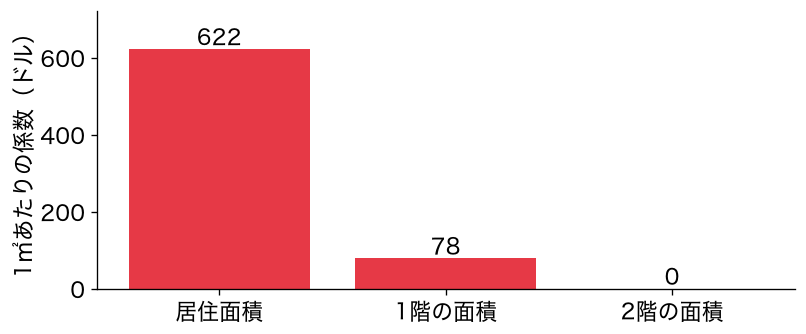

- キッチン数−17,708ドル、寝室数−7,829ドルは残る
- 「ほかの列を同じにしたら」を付けて読む。同じ広さで寝室が多いと1部屋が狭い

## お手本：1軒目の家

5節 ② 査定する●○○○○○

```python
house = df.iloc[[0]]
Z_h = standardize(house[cols], mean_all, std_all)
pred_h = lasso_all.predict(Z_h)[0]
price = house['価格'].iloc[0]
print(f'査定額：{pred_h:,.0f}ドル（実際の価格は{price:,}ドル）')
```

- 新しい家も、式を作ったときと同じ物差しで標準化してから当てる

## 1軒目は206,773ドル

5節 ② 査定する●●○○○○

```
査定額：206,773ドル（実際の価格は215,000ドル）
```

- 第4回の10本の式では211,548ドルだった

## 1軒では比べられない

5節 ② 査定する●●●○○○

- 査定額は数千ドル違うが、どちらが良いかは1軒では決まらない
- 式の良し悪しは交差検証で比べる。17,148ドル対19,297ドル

## TODO③：別の家を査定する

5節 ② 査定する●●●●○○

```python
# TODO: 6軒目の家（df.iloc[[5]]）をラッソの式で査定する
# ヒント: house = df.iloc[[5]] にして、お手本のセルを写す
...
```

- お手本のセルを写し、`0`を`5`に変える

## やってみよう：5節とTODO③

5節 ② 査定する●●●●●○

- 5節のお手本を実行し、係数と1軒目の査定額を確かめる
- TODO③で、6軒目の家を査定する

動画の人は、ここで一時停止。

## 答え合わせ：TODO③

5節 ② 査定する●●●●●●

```python
house = df.iloc[[5]]
Z_h = standardize(house[cols], mean_all, std_all)
pred_h = lasso_all.predict(Z_h)[0]
price = house['価格'].iloc[0]
print(f'査定額：{pred_h:,.0f}ドル（実際の価格は{price:,}ドル）')
```

```
査定額：196,095ドル（実際の価格は195,500ドル）
```

## 答え：説明できる係数は保てる

5節 ③ 答え●○

列を30本に増やすと、交差検証のMAEは19,297ドルから17,188ドルに小さくなる。ただ、和でつながった列があり、係数の内訳は決まらない。ラッソ（`alpha`=300、交差検証で選んだ）なら、当たりは17,148ドルのまま、4本の係数が0になり、居住面積は1㎡622ドルと説明に使える大きさに戻る。

## ただし読み方は変わらない

5節 ③ 答え●●

- 当たりを良くしながら、説明できる係数を保つことはできる
- ただし「ほかの列を同じにしたら」を付けて読む必要は残る

## まだ言えないこと①：揺れ

5節 ④ まだ言えないこと●○○

- ラッソが0にする列は、分け方を変えると入れ替わることがある
- これは発展で見る

## まだ言えないこと②：外した列

5節 ④ まだ言えないこと●●○

- 間口の長さは、欠測の理由が分からず使わなかった
- 地区や外壁の材料などの文字の列も、まだ式に入れていない

## まだ言えないこと③：列が多いとき

5節 ④ まだ言えないこと●●●

- 今日は30本と2,412軒だった
- 列のほうがずっと多いデータでは、普通の式はどうなるか（発展で見る）

# まとめ

## 今日の道筋を振り返る

⑥ 振り返る●○○○○

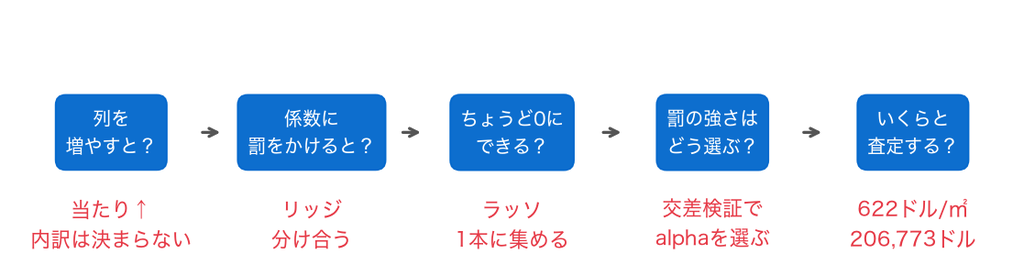

- 5つの小さな問いに答えて、説明できる係数を保った式にたどり着いた

## 今日の歩み

⑥ 振り返る●●○○○

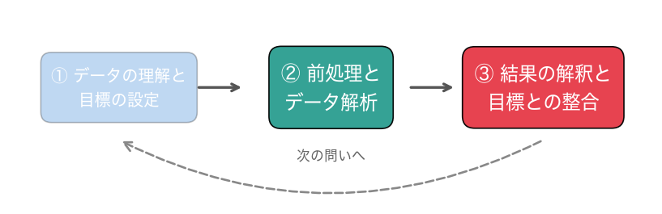

列を増やす → 完全な多重共線性 → リッジ → ラッソ → 交差検証でalpha → 査定

## 今日持ち帰る1文

⑥ 振り返る●●●○○

列を増やすと当たりは良くなるが、似た列の係数は決まらなくなる。係数に罰をかけて（正則化）係数を落ち着かせ、罰の強さは交差検証で選ぶ。

## 今日の要点①：正則化

⑥ 振り返る●●●●○

- 足すとほかの列になる列があると、係数の和は決まっても内訳は決まらない
- 正則化は、係数の大きさへの罰を足して係数を1つに決める。罰の前に訓練の物差しで標準化
- リッジは似た列で分け合い、ラッソはいくつかの係数をちょうど0にする

## 今日の要点②：選び方と道具

⑥ 振り返る●●●●●

- 罰の強さ`alpha`は交差検証で選ぶ。弱すぎても強すぎても当たりは悪くなる
- Python：初めての道具はドキュメントで目的関数と引数を読む。同じ名前でも物差しが違うことがある
- 警告は読み飛ばさない。モデルを引数にして交差検証の部品を差し替える

## 課題の出し方

⑦ このあと●○○○

- ノートの最後の「課題（提出）」に取り組む
- 応用②の答えと応用③の文章を、LACSに入力して提出（＝出席。期限なし）
- AIを使ってもよい。何を聞いて、どう直したかを1行書く

## 次回予告：区分を当てる

⑦ このあと●●○○

- ここまでは、価格や台数のような数を当ててきた
- 当てたいものが、「病気か、そうでないか」のような区分だったら

## 次回の問い

⑦ このあと●●●○

検査の値から、患者が心臓病かどうかを、どう見分けるか？

## このあと：課題へ

⑦ このあと●●●●

ノートの「課題（提出）」へ。alphaを1000にしたラッソで、0になる列と当たりを確かめます。

# ここから先は解答

## 課題のあとで見る

課題（提出）に取り組んでから見てください。動画の人は、ここで一時停止。

## 応用①：alpha=1000

```python
lasso1000 = cv_model(cols, Lasso(alpha=1000), '居住面積')
print(lasso1000)
print(lasso1000['MAE'].mean())
l1000 = Lasso(alpha=1000).fit(Z_all, df['価格'])
coef1000 = pd.Series(l1000.coef_, index=cols)
print(list(coef1000[coef1000 == 0].index))
print((coef1000 == 0).sum(), '本')
```

## 当たりはほぼ同じ

```
     MAE   係数  0の数
0  17816  593   11
1  17170  609   10
2  16959  611    9
3  17051  620   10
4  16969  615    9
17193.0
```

- MAEは17,193ドル。`alpha`=300（17,148ドル）とほとんど同じ

## 9本が0になった

```
['地下の未仕上げ', '2階の面積', '地下の洗面所', 'バスルーム数', '洗面所の数', '部屋数', '囲いポーチ', '三季ポーチ', 'プールの面積']
9 本
```

- 部屋数やポーチ・プールの面積も式から外れた

## 応用②：答えは9

- `alpha`=1000のラッソで、係数が0になった列は9本
- `alpha`=300では4本だった

## 応用③：模範例

`alpha`=1000のラッソは、交差検証のMAEが17,193ドルで、`alpha`=300（17,148ドル）とほとんど変わりません。そのうえで、0になる列が4本から9本に増えます。お客さんへの説明では効く列が少ないほうが話しやすいので、`alpha`=1000を選びます。ただし、外れた列は価格に関係ないのではなく、ほかの列と重なっているだけだと付け加えます。

## 書き方の型

- 1文目：自分の出力の数値で、2つの`alpha`のMAEを比べる
- 2文目：0になる列の数の違いと、説明のしやすさ
- 3文目：判断と、外れた列の読み方の注意

# 発展（任意）

## 0になる列は揺れるか

- 全部の家の式では、4本の係数が0になった
- 交差検証の5回の訓練それぞれで作ったら、同じ列が0になるか

## お手本：回ごとの0の列

```python
for tr_i, te_i in kf.split(df):
    tr_s = df.iloc[tr_i]
    mean, std = tr_s[cols].mean(), tr_s[cols].std()
    m_s = Lasso(alpha=300).fit(standardize(tr_s[cols], mean, std),
                               tr_s['価格'])
    coef_s = pd.Series(m_s.coef_, index=cols)
    print(list(coef_s[coef_s == 0].index))
```

## 回ごとに顔ぶれが違う

```
['地下の未仕上げ', '2階の面積', 'バスルーム数', '洗面所の数', '開放ポーチ']
['地下の未仕上げ', '2階の面積', '洗面所の数', '囲いポーチ']
['地下の未仕上げ', '2階の面積', '洗面所の数']
['地下の未仕上げ', '2階の面積', 'バスルーム数', '洗面所の数', 'プールの面積']
['地下の未仕上げ', '2階の面積', '洗面所の数']
```

- 5回とも0：地下の未仕上げ・2階の面積・洗面所の数。バスルーム数は2回だけ

## 外した列も揺れる

- 効きの弱い列や重なる列は、訓練の家が少し変わるだけで残ったり外れたりする
- ラッソが外した列を「価格に関係ない列」と読むのは危険

## 列が家より多いとき

- 今日は2,412軒に30本。列のほうがずっと多いデータでは何が起きるか
- 正則化がいちばん力を発揮するのは、こうしたデータ

## ラットの目の遺伝子発現

- ラットの目の組織で、遺伝子の働き（発現量）を測ったデータ
- 120匹。TRIM32という遺伝子の発現量を、ほかの200個の遺伝子から当てる
- 出典：Scheetzほか（2006, PNAS）、NCBI GEOのGSE5680

## 行より列が多い

```python
rat = pd.read_csv(f'{DATA_DIR}/rat_eye.csv', index_col=0)
y_rat = rat['TRIM32']
X_rat = rat.drop(columns='TRIM32')
print(X_rat.shape)
print(round(np.abs(y_rat - y_rat.mean()).mean(), 3))  # 平均で答える
```

```
(120, 200)
0.094
```

## 訓練96匹に200本

- 交差検証の各回の訓練は96匹。列は200本
- 普通の線形回帰は、訓練の96匹を誤差0で通る式をいくらでも作れる

## お手本：普通の式とラッソ

```python
def cv_rat(model):
    r2, err, used = [], [], []
    for tr_i, te_i in kf.split(X_rat):
        X_tr, X_te = X_rat.iloc[tr_i], X_rat.iloc[te_i]
        y_tr, y_te = y_rat.iloc[tr_i], y_rat.iloc[te_i]
        mean, std = X_tr.mean(), X_tr.std()
        m_s = model.fit(standardize(X_tr, mean, std), y_tr)
        r2.append(m_s.score(standardize(X_tr, mean, std), y_tr))
        pred_s = m_s.predict(standardize(X_te, mean, std))
        err.append(np.abs(y_te - pred_s).mean())
        used.append((m_s.coef_ != 0).sum())
    print(round(np.mean(r2), 3), round(np.mean(err), 3), used)

cv_rat(LinearRegression())
cv_rat(Lasso(alpha=0.02, max_iter=100000))
```

[output not shown]

## 普通の式は平均に負ける

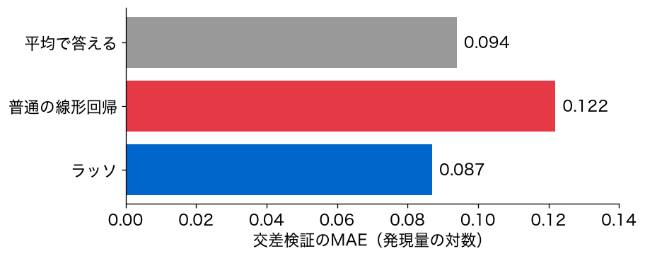

- 普通の式は訓練のR²が1.0なのに、テストのMAEは0.122で平均（0.094）より悪い

## ラッソなら当たる

- ラッソ（`alpha`=0.02）は、テストのMAEが0.087で平均より良い
- 使った遺伝子は、200個のうち回ごとに9〜18個

## 正則化の本領

- 列が行より多いデータでは、正則化なしでは当たる式が作れない
- 遺伝子のデータで、ラッソが広く使われるようになった理由

## RidgeCVとLassoCV

- 交差検証で`alpha`まで選ぶ道具。ドキュメントで`alphas`と`cv`を読む
- そのまま渡すと標準化を交差検証の中で行わない。比べるだけにする

## お手本：選ばれるalpha

```python
from sklearn.linear_model import RidgeCV, LassoCV
r_cv = RidgeCV(alphas=[1, 10, 30, 100, 300, 1000], cv=kf,
               scoring='neg_mean_absolute_error')
r_cv.fit(Z_all, df['価格'])
l_cv = LassoCV(alphas=[10, 30, 100, 300, 1000, 3000], cv=kf,
               max_iter=100000).fit(Z_all, df['価格'])
print(r_cv.alpha_, l_cv.alpha_)
```

```
100 30
```

## 何で選んだかを読む

- リッジは100で、4節と同じ。ラッソは30で、4節の300と違う
- `LassoCV`は、MAEではなく誤差の二乗の平均（`mse_path_`）で`alpha`を選ぶ

## 試すなら

- `LassoCV`のドキュメントで`alphas`を読む。整数を渡すと、その個数の`alpha`を自動で並べて試す
- `alphas=100`にして使ってみる

## おわり

- 今日は、列を30本に増やし、ラッソで説明できる係数を保った
- 1軒目の家の査定額は、206,773ドル